# *Deep Learning based Car Identification*

##### *- Automotive, Surveillance, Object Detection & Localisation*

*Project By:*  
Premjeet Kumar https://www.linkedin.com/in/premjeet-kumar/  
Hari Samynaath S https://www.linkedin.com/in/harinaathan/  
Veena Raju https://www.linkedin.com/in/veena-raju-1b16b513b/  
Javed Bhai https://www.linkedin.com/in/javedbhai/  
Surabhi Joshi https://www.linkedin.com/in/surabhi-joshi-4452788/

*Project For:*  
Captstone project for **Post Graduate Program in Artificial Intelligence and Machine Learning**  
with *GreatLakes & Texas McCombs School of Business, The University of Texas at Austin*

**CONTEXT:**  
Computer vision can be used to automate supervision and generate action appropriate action trigger if the event is predicted from the image of interest. For example a car moving on the road can be easily identi ied by a camera as make of the car, type, colour, number plates etc.  
**DATA DESCRIPTION:**  
The Cars dataset contains 16,185 images of 196 classes of cars. The data is split into 8,144 training images and 8,041 testing images, where each class has been split roughly in a 50-50 split. Classes are typically at the level of Make, Model, Year, e.g. 2012 Tesla Model S or 2012 BMW M3 coupe.  
‣ *Train Images:* Consists of real images of cars as per the make and year of the car.  
‣ *Test Images:* Consists of real images of cars as per the make and year of the car.  
‣ *Train Annotation:* Consists of bounding box region for training images.  
‣ *Test Annotation:* Consists of bounding box region for testing images.

### **MILESTONE 1:**

‣ *Step 1:* Import the data  
‣ *Step 2:* Map training and testing images to its classes.  
‣ *Step 3:* Map training and testing images to its annotations.  
‣ *Step 4:* Display images with bounding box  
‣ *Output:* Images mapped to its class and annotation ready to be used for deep learning

### **MILESTONE 2:**

‣ *Input:* Output of milestone 1  
‣ *Step 1:* Design, train and test CNN models to classify the car.  
‣ *Step 2:* Design, train and test RCNN & its hybrids based object detection models to impose the bounding box or mask over the area of interest.  
‣ *Output:* Pickled model to be used for future prediction

```python
from lib.networkPipe import Pipe
```

```
Metal device set to: Apple M1 Pro
```

[output not shown]

```python
logdir = "logs"
%load_ext tensorboard
%tensorboard --logdir logs
```

[interactive chart not shown]

```python
# define a transfer learning network mapped to our targets
def transferNET(application,input_size):

    import tensorflow as tf
    from tensorflow.keras.models import Model
    from tensorflow.keras.layers import Input,GlobalMaxPool2D,Dense,BatchNormalization,Dropout

     # Random consistency seed
    tf.random.set_seed(100)

    # load application
    tNet = application(input_shape=input_size[1:],include_top=False, weights='imagenet')

    # flatten with pooling
    pool = GlobalMaxPool2D(name="CustomLayerStart")(tNet.output)

    # classifier branch for car names
    nameBranch = Dense(512,activation='relu')(pool)
    Nbn1 = BatchNormalization()(nameBranch)
    Ndo1 = Dropout(0.3)(Nbn1)
    Nhid1 = Dense(256,activation='relu')(Ndo1)
    Nbn2 = BatchNormalization()(Nhid1)
    Ndo2 = Dropout(0.3)(Nbn2)
    classifier = Dense(196,activation='softmax',name="names")(Ndo2)

    # regression branch for bounding boxes
    boxBranch = Dense(64,activation='relu')(pool)
    Bbn1 = BatchNormalization()(boxBranch)
    Bdo1 = Dropout(0.3)(Bbn1)
    Bhid1 = Dense(32,activation='relu')(Bdo1)
    Bbn2 = BatchNormalization()(Bhid1)
    Bdo2 = Dropout(0.3)(Bbn2)
    bBox = Dense(4,activation='relu',name="boxes")(Bdo2)

    # assemble the network
    model = Model(inputs=tNet.inputs,outputs=[classifier,bBox])

    # freeze application layers and open classifer & regressor for training
    for layer in model.layers[:-15]:
        layer.trainable = False

    return model
```

```python
from tensorflow.keras.optimizers import Adam
from tensorflow.keras.applications.resnet_v2 import ResNet50V2
```

```python
gPoint = {'width':224,
          'optimizer':Adam,
          'patience':5,'slope':0.3,'factor':0.1,
          'unFreezeRatio':None,
          'learning_rate':1e-3,'lossBalance':0.5}
```

```python
# generator parameters
dims = (gPoint.get('width'),gPoint.get('width'))
gParams = dict(target_size=dims,batch_size=32)
# model creation parameters
mParams = dict(application=ResNet50V2)
# optimiser for compilation
optim = gPoint.get('optimizer')
# lr scheduler parameters
lrParams = dict(patience=gPoint.get('patience'),slope=gPoint.get('slope'),factor=gPoint.get('factor'))
# earlyStop parameters
eSparams = dict(patience=int(gPoint.get('patience')*3.1),slope=gPoint.get('slope')*0.5)
# model fitting parameters
fParams = dict(epochs=30,verbose=1)
# trainability scheduler parameters
if gPoint.get('unFreezeRatio')==None:
    trParams = dict()
else:
    trParams = dict(uncontrolled=-15,schedule={int(gPoint.get('patience')*2.8):gPoint.get('unFreezeRatio')})
# other hyper parameters
lRate = gPoint.get('learning_rate')
lBalance = gPoint.get('lossBalance')
gridPoint = dict(learning_rate=lRate,lossWeights={'names':lBalance,'boxes':1-lBalance})
```

```
Downloading data from https://storage.googleapis.com/tensorflow/keras-applications/resnet/resnet50v2_weights_tf_dim_ordering_tf_kernels_notop.h5
```

[output not shown]

```
2022-07-29 19:10:24.048458: I tensorflow/core/grappler/optimizers/custom_graph_optimizer_registry.cc:113] Plugin optimizer for device_type GPU is enabled.
```

```
---------------------------------------------------------------
eStop initiated after epoch  18 for poor loss gradient of 0.148
---------------------------------------------------------------


----------
EVALUATION
----------
```

```
2022-07-29 19:58:28.063436: W tensorflow/python/util/util.cc:368] Sets are not currently considered sequences, but this may change in the future, so consider avoiding using them.
```

```
INFO:tensorflow:Assets written to: ./deployables/ResNet50V2/ResNet50V2/tfsave/assets
```

|  | name | target_size | batch_size | optimizer | patience | slope | factor | learning_rate | lossWeights | epochs | verbose | logs | loss | names_loss | boxes_loss | names_CategoricalAccuracy | names_Precision | names_Recall | boxes_IoU | val_loss | val_names_loss | val_boxes_loss | val_names_CategoricalAccuracy | val_names_Precision | val_names_Recall | val_boxes_IoU |
| --- | --- | --- | --- | --- | --- | --- | --- | --- | --- | --- | --- | --- | --- | --- | --- | --- | --- | --- | --- | --- | --- | --- | --- | --- | --- | --- |
| 0 | ResNet50V2 | (224, 224) | 32 | Adam | 15 | 0.15 | 0.1 | 0.001 | {'names': 0.5, 'boxes': 0.5} | 30 | 1 | {'loss': [5.000739574432373, 3.436673164367676... | 0.369423 | 0.350934 | 0.018489 | 0.935778 | 0.981474 | 0.912525 | 0.587236 | 2.480897 | 2.462386 | 0.018511 | 0.408989 | 0.657504 | 0.259089 | 0.589307 |

```
----------
PREDICTION
----------
```

```
2022-07-29 19:58:39.644274: I tensorflow/core/grappler/optimizers/custom_graph_optimizer_registry.cc:113] Plugin optimizer for device_type GPU is enabled.
```

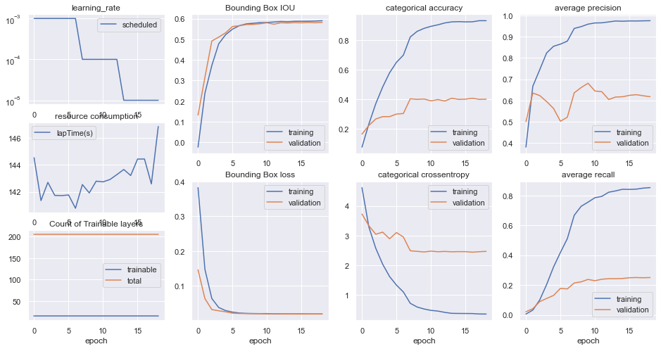

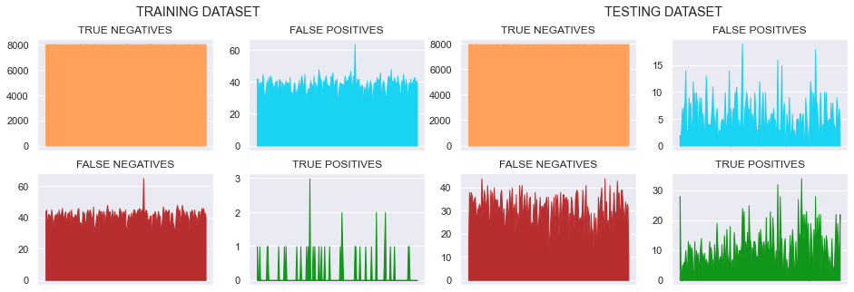

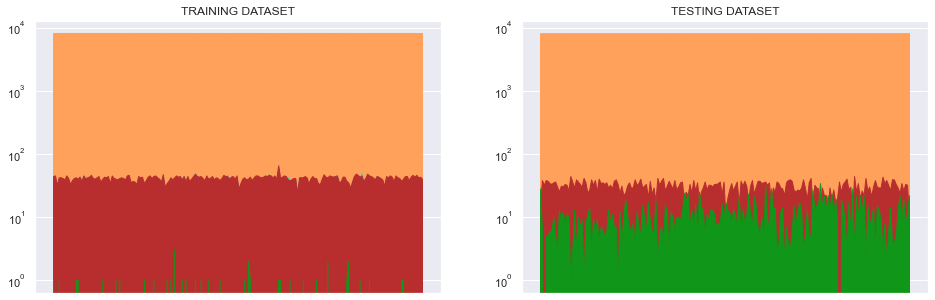

```
samples from TRAINING SET
```

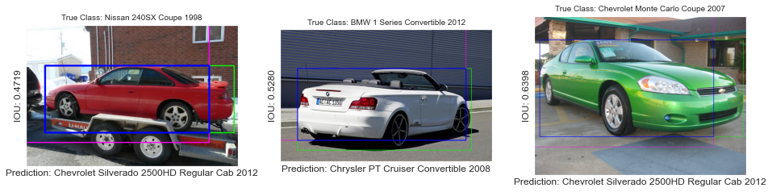

```
samples from TESTING SET
```

[figure not shown]

```python
pp = Pipe(generatorParams=gParams,modelFunc=transferNET,
          modelName="ResNet50V2",modelParams=mParams)
pp.compiler(optim=Adam(),lrScheduleParams=lrParams,eStopParams=eSparams,
            trainabilityParams=trParams,gridPoint=gridPoint,sBest=True)
pp.fit(gridPoint=gridPoint,fitParams=fParams)
pp.evaluate()
pp.save()
pp.report()
```